# MACHINE LEARNING WORKFLOW

George

2022-02-28

Table of content

List of figures

List of tables

# Introduction.

The goal of this analysis is to predict with precision the probability of customer churn and consequently help in customer retention and mitigation of the risks related to customer churn.

## Business Value

Below are some the business values that this analysis will create:

1. Reduce churn rate by detecting early clients who are about to churn.
2. Increase customer retention.
3. Understand customer base better based on their activity.

## Dataset

The data set used in this project was sourced from client transaction data recorded since the inception of the financial institution.Based in this data set,informative feature sets were created which were subsequently used in the predictive model.

The clients records included in this study were selected from those who were determined to have done at least one transaction within the banking platform.

# Dataset Overview

## Data Quality

### Dataset Dimensions.

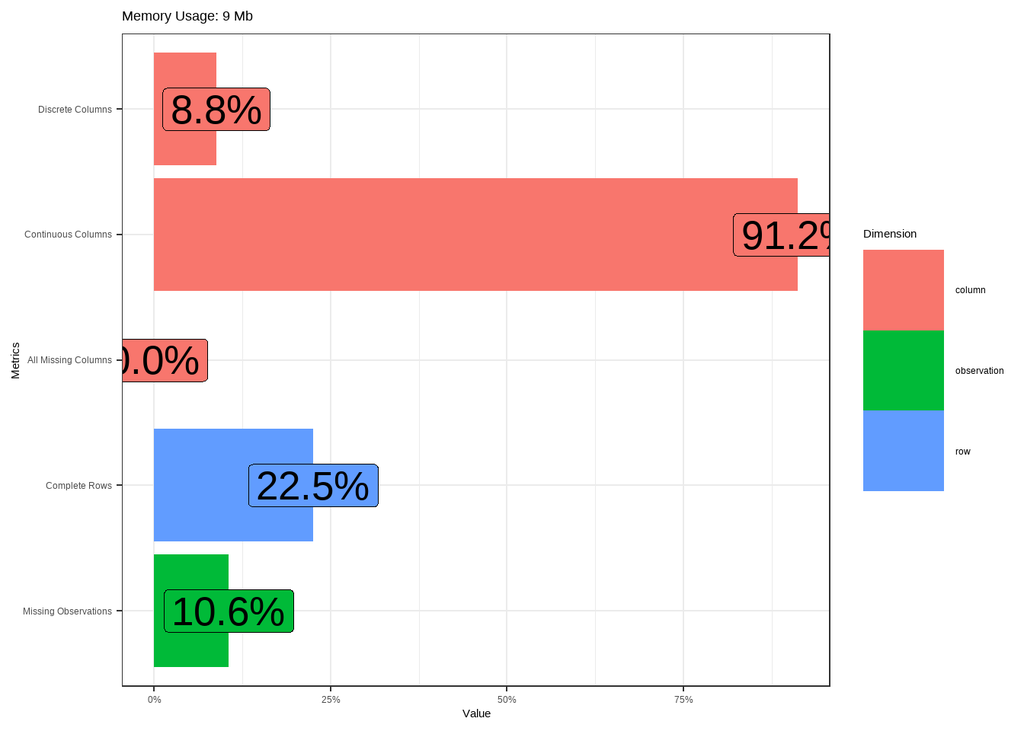

TRUE

The dataset under study had 12512 records and 91 variables inclusive of target variable.

### Variable Explanations.

### Quality

**Observations and Inferences**

From the above ,it was noticed that a number of variables had missing values.The missing values occurrence where however systematic showing an indication that the client had never used the service/product before.These will later require imputation.

# Exploratory Data Analysis.

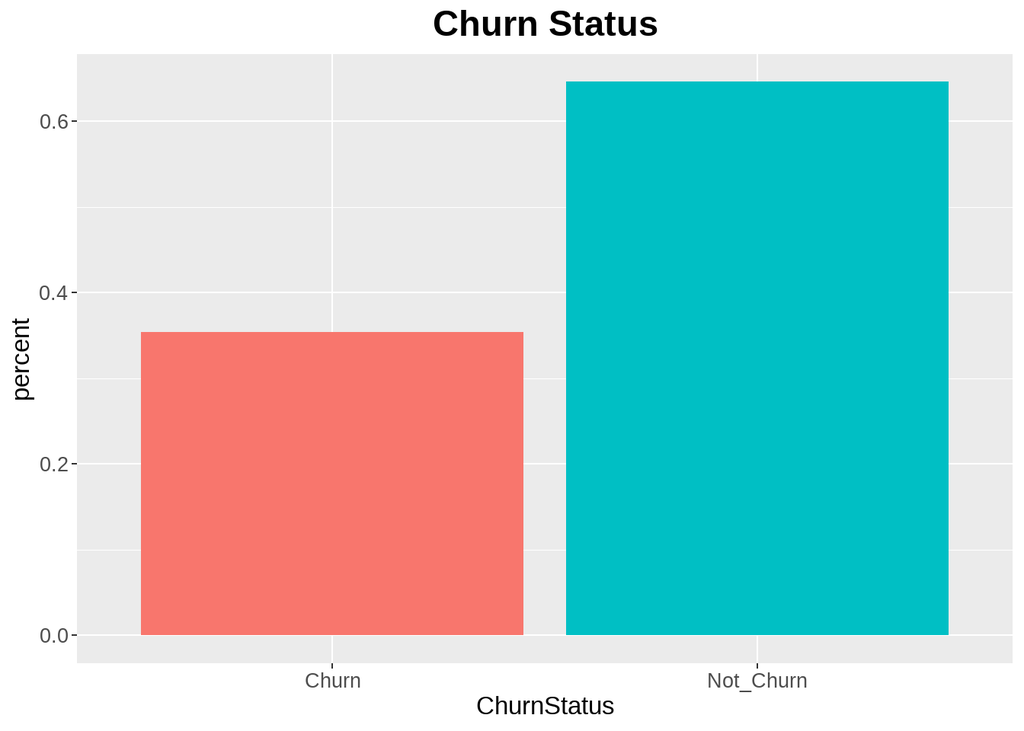

TRUE

**Observations and inferences**

As we can observe from above,the institution had a 35% churn rate.

### Explanatory Variables

#### Categorical Variables

[output not shown]

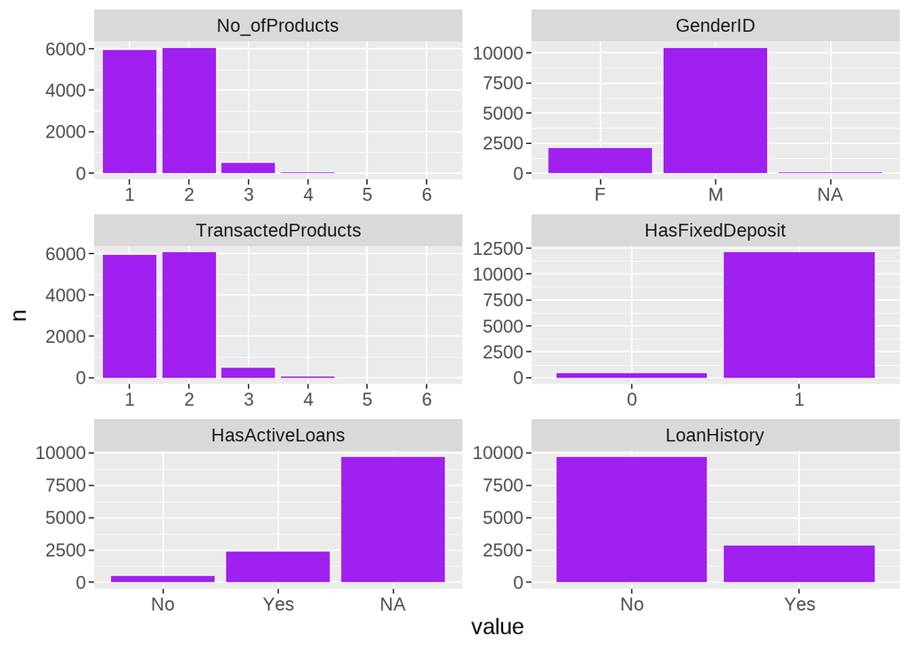

TRUE

**Observations and inference**

#### Numerical Variables

##### Deposits transactions count Related

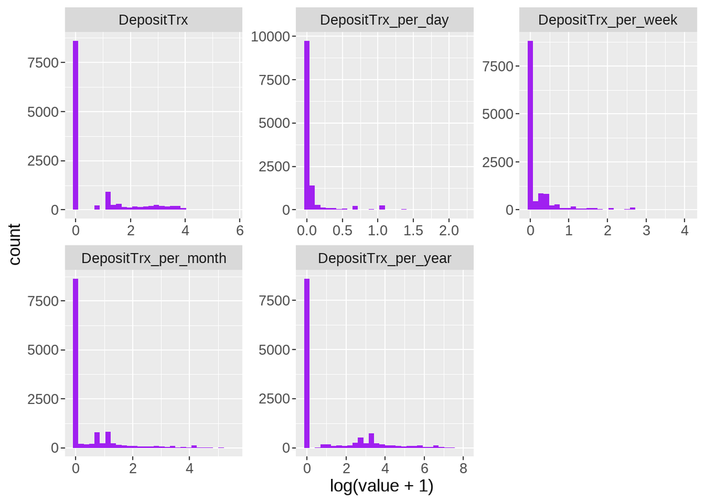

TRUE

##### Deposit transaction amount Related

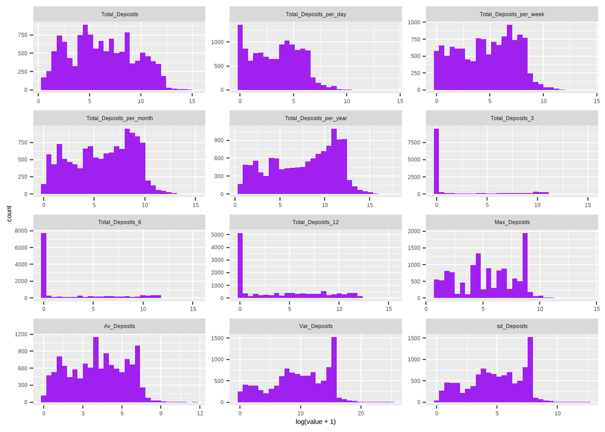

TRUE

##### Transaction Count Related

###### Visualization

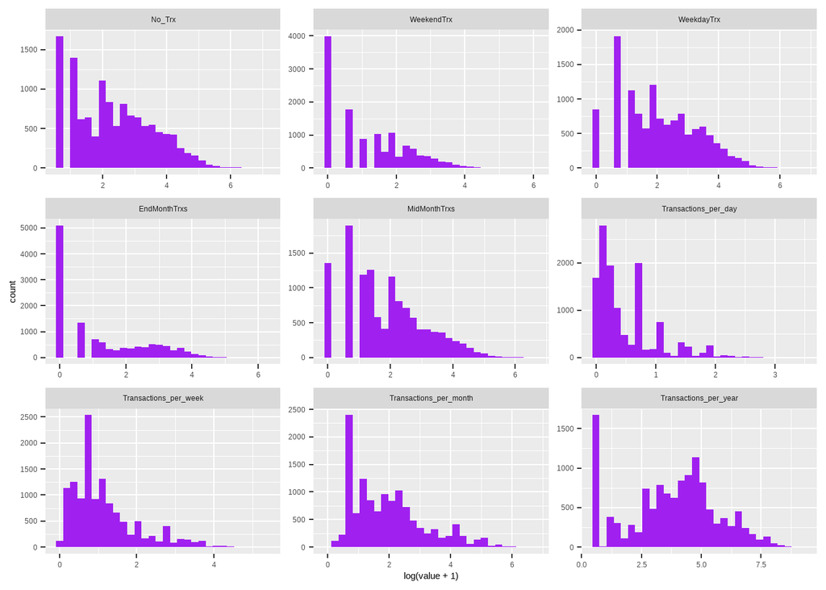

TRUE

**Observations and Inferences**

##### Withdrawals Related

###### Visualization

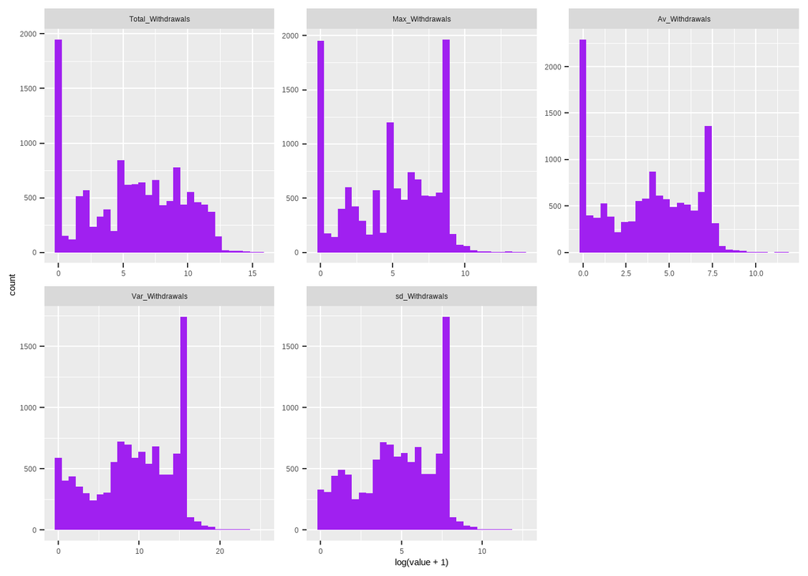

TRUE

## Bivariate Analaysis

### Target Variable Vs Categorical Variables

#### Descriptive Statistics

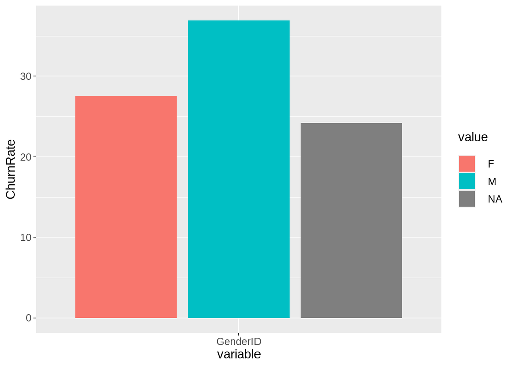

TRUE

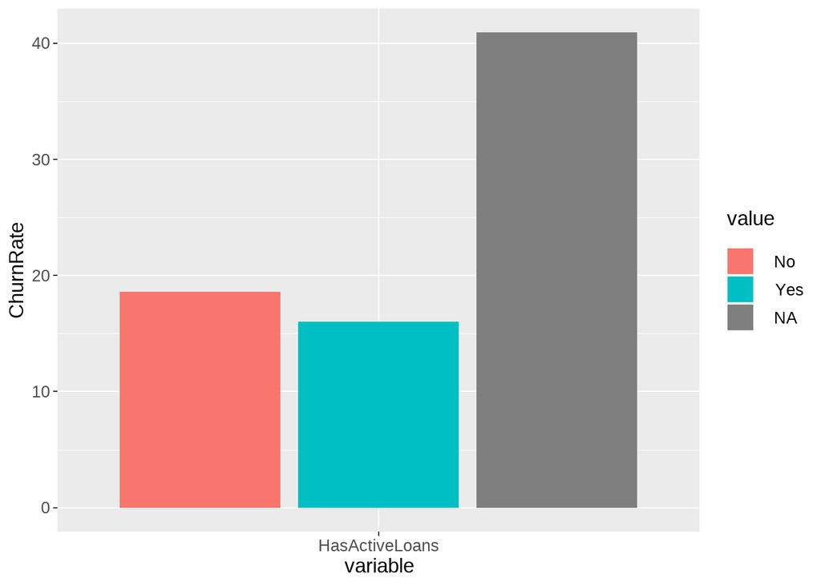

TRUE

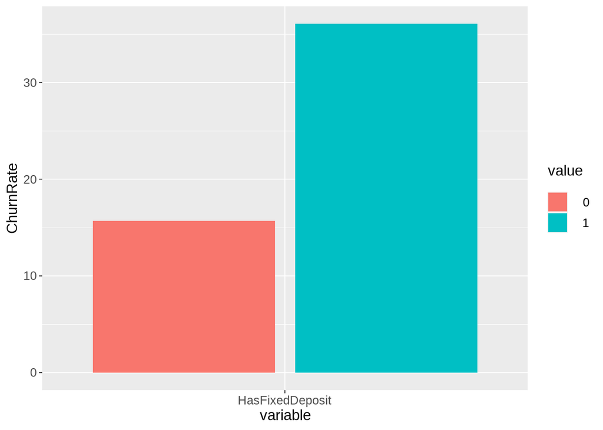

TRUE

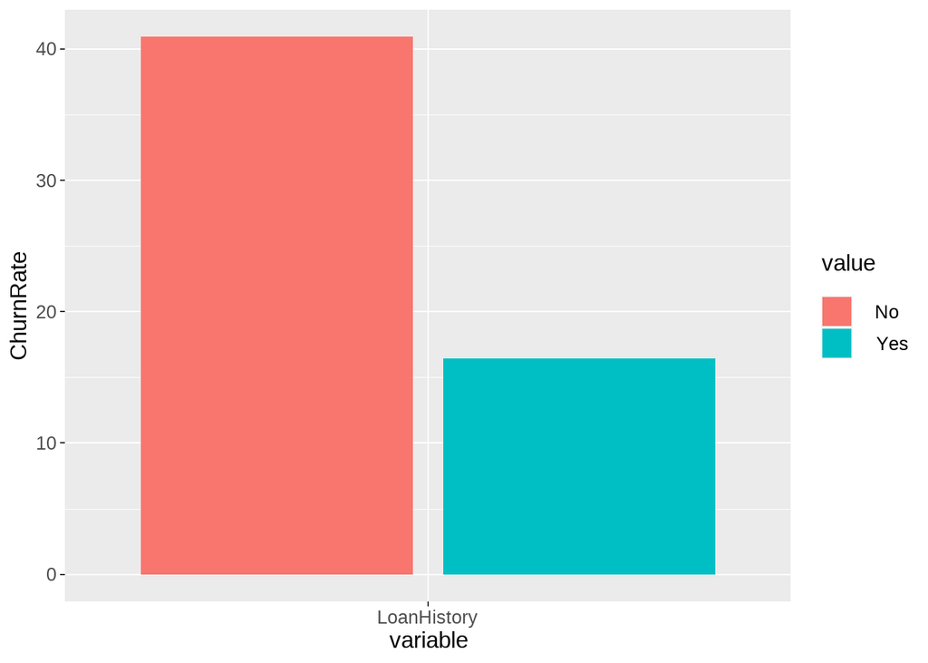

TRUE

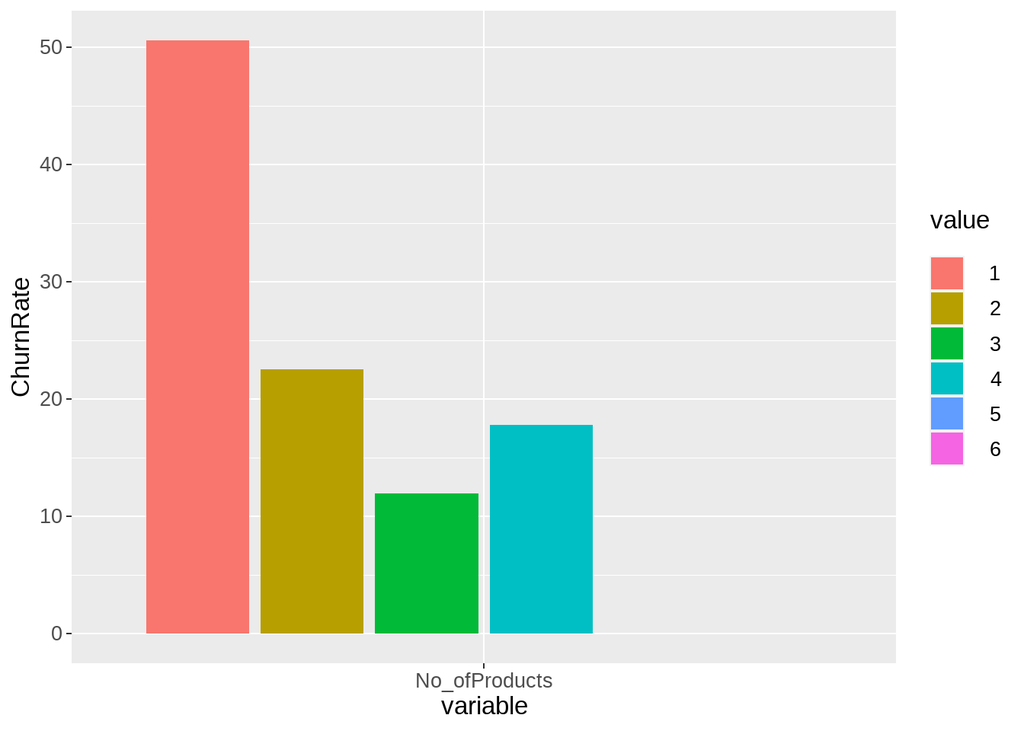

TRUE

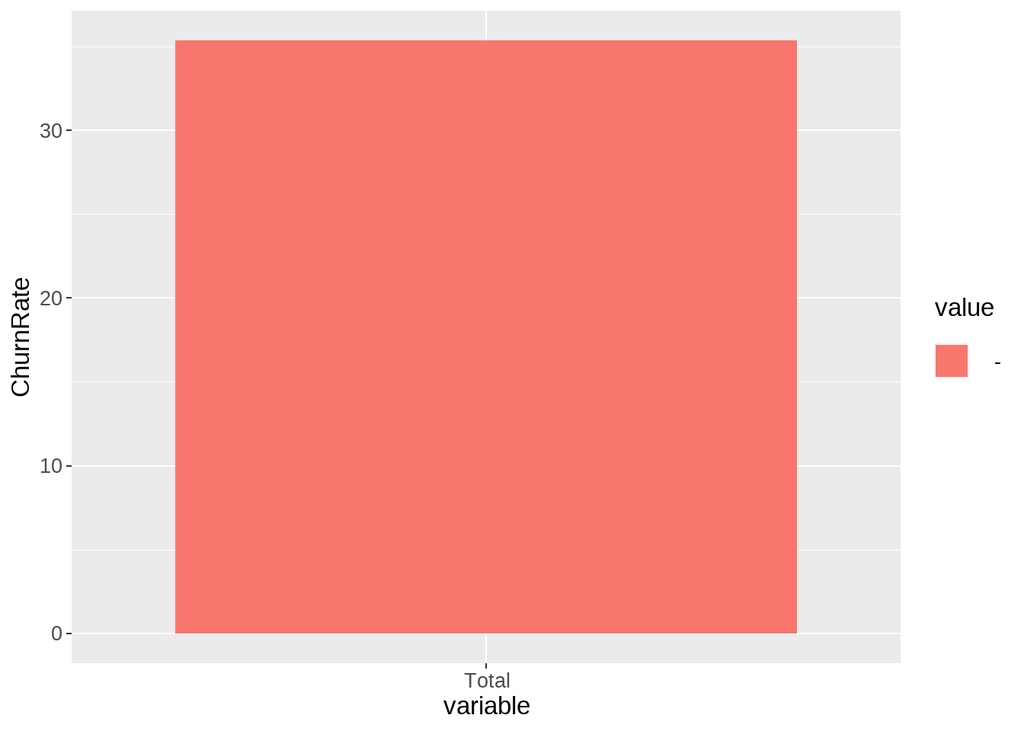

TRUE

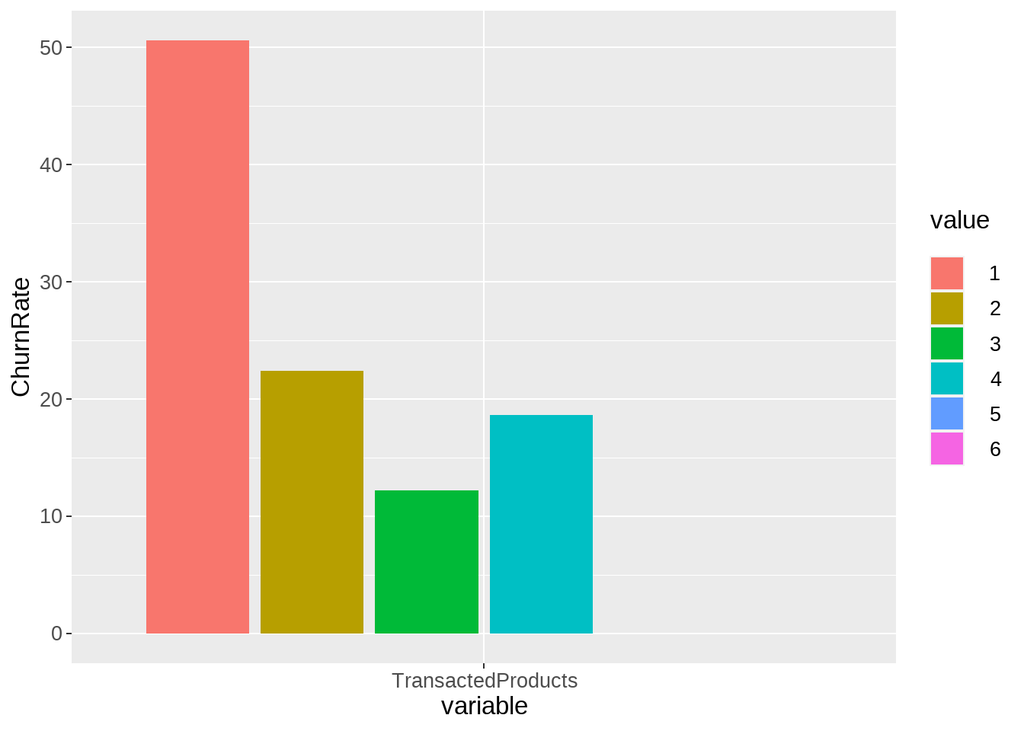

TRUE

### Target Variable Vs Numerical Variables

##### Deposits transactions count Related

###### Visualization

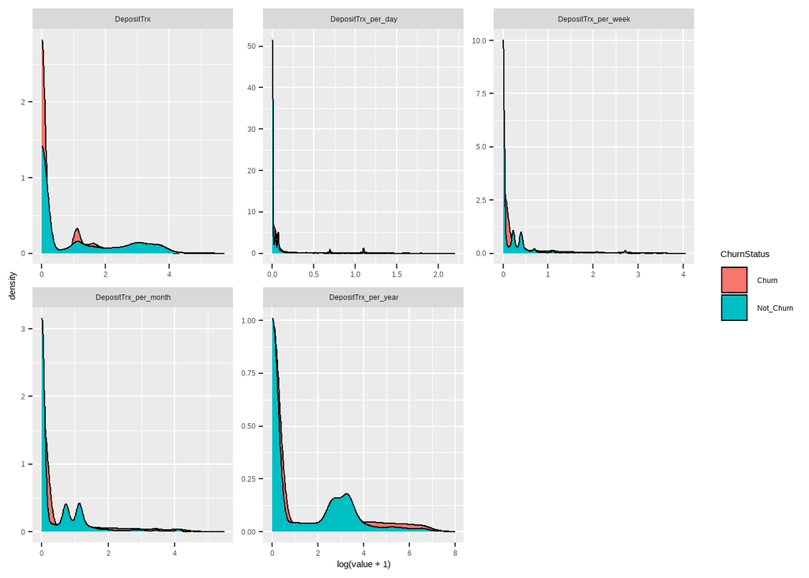

TRUE

### Correlation Analysis.

In order to plot correlation,features that exhibited some distributions were selected.

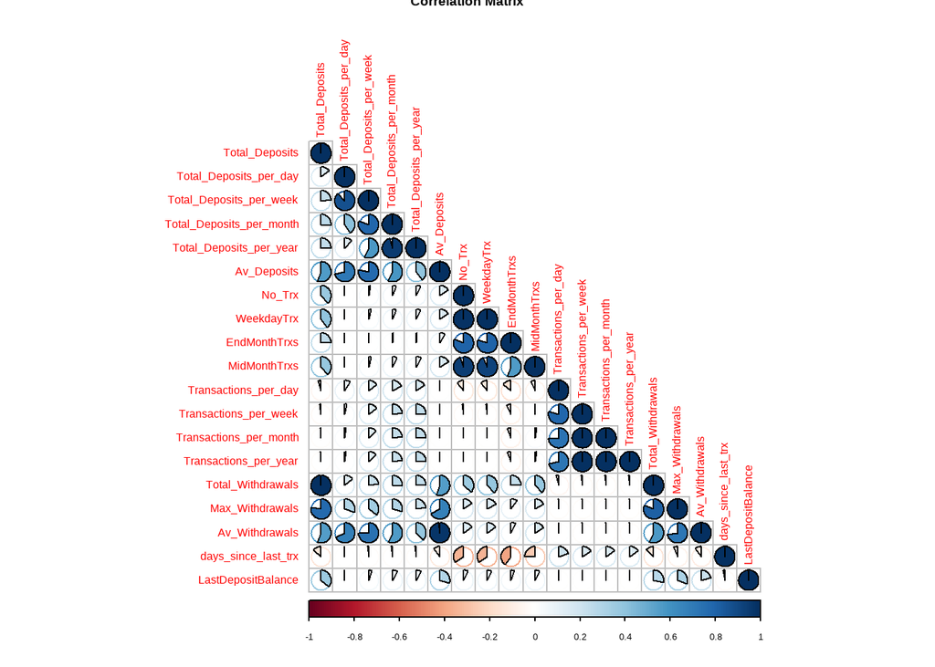

TRUE

Observations and Inferences

- Some variables are highly correlated with others. eg Total withdrawals vs Total deposits.
- This correlation will be dealt with at feature engineering phase.

**Variable Selection for the next stage of analysis**

## Machine Learning Modelling Phase

## Reading Data

### Train Test Split

In order to maintain the ratio of churn status in the train and test splits ,a stratified split was performed with respect to the Churn Status.

### Data Preprocessing with recipes

### Logistic Regression

#### Logistic Model Results

```
## Confusion Matrix and Statistics
##
##
##        0    1
##   0 1543  442
##   1  479  664
##
##                Accuracy : 0.7056
##                  95% CI : (0.6892, 0.7215)
##     No Information Rate : 0.6464
##     P-Value [Acc > NIR] : 1.303e-12
##
##                   Kappa : 0.3607
##
##  Mcnemar's Test P-Value : 0.2355
##
##             Sensitivity : 0.7631
##             Specificity : 0.6004
##          Pos Pred Value : 0.7773
##          Neg Pred Value : 0.5809
##              Prevalence : 0.6464
##          Detection Rate : 0.4933
##    Detection Prevalence : 0.6346
##       Balanced Accuracy : 0.6817
##
##        'Positive' Class : 0
##
```

#### Variable Selection

## Decision Trees

### Recipe

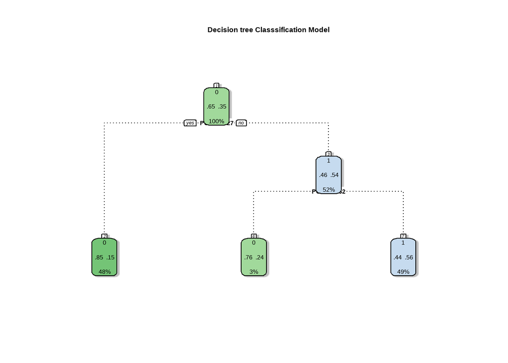

TRUE

```
## Confusion Matrix and Statistics
##
##           Reference
## Prediction    0    1
##          0 1350  284
##          1  672  822
##
##                Accuracy : 0.6944
##                  95% CI : (0.6779, 0.7105)
##     No Information Rate : 0.6464
##     P-Value [Acc > NIR] : 7.894e-09
##
##                   Kappa : 0.3806
##
##  Mcnemar's Test P-Value : < 2.2e-16
##
##             Sensitivity : 0.6677
##             Specificity : 0.7432
##          Pos Pred Value : 0.8262
##          Neg Pred Value : 0.5502
##              Prevalence : 0.6464
##          Detection Rate : 0.4316
##    Detection Prevalence : 0.5224
##       Balanced Accuracy : 0.7054
##
##        'Positive' Class : 0
##
```

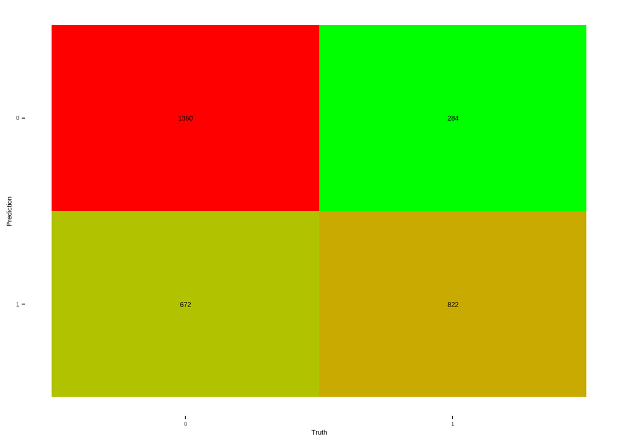

TRUE

### Random Forest

```
## Confusion Matrix and Statistics
##
##           Reference
## Prediction    0    1
##          0 1634  377
##          1  388  729
##
##                Accuracy : 0.7554
##                  95% CI : (0.74, 0.7704)
##     No Information Rate : 0.6464
##     P-Value [Acc > NIR] : <2e-16
##
##                   Kappa : 0.4662
##
##  Mcnemar's Test P-Value : 0.7177
##
##             Sensitivity : 0.8081
##             Specificity : 0.6591
##          Pos Pred Value : 0.8125
##          Neg Pred Value : 0.6526
##              Prevalence : 0.6464
##          Detection Rate : 0.5224
##    Detection Prevalence : 0.6429
##       Balanced Accuracy : 0.7336
##
##        'Positive' Class : 0
##
```

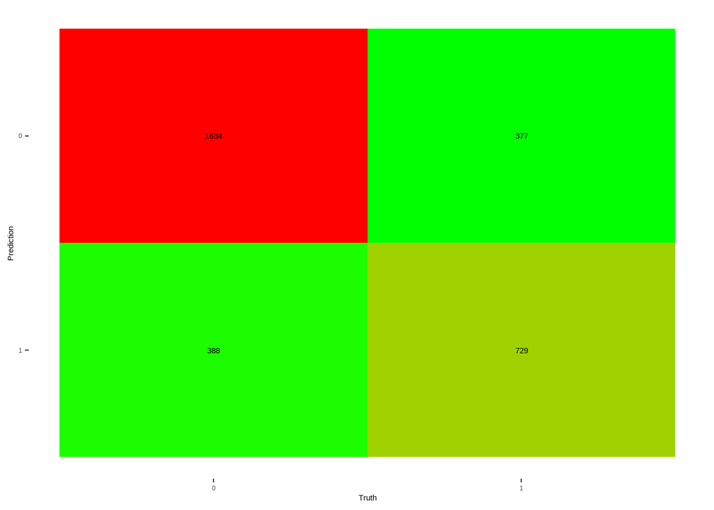

TRUE

## SVM

```
## Confusion Matrix and Statistics
##
##           Reference
## Prediction    0    1
##          0 1523  369
##          1  499  737
##
##                Accuracy : 0.7225
##                  95% CI : (0.7065, 0.7381)
##     No Information Rate : 0.6464
##     P-Value [Acc > NIR] : < 2.2e-16
##
##                   Kappa : 0.4087
##
##  Mcnemar's Test P-Value : 1.195e-05
##
##             Sensitivity : 0.7532
##             Specificity : 0.6664
##          Pos Pred Value : 0.8050
##          Neg Pred Value : 0.5963
##              Prevalence : 0.6464
##          Detection Rate : 0.4869
##    Detection Prevalence : 0.6049
##       Balanced Accuracy : 0.7098
##
##        'Positive' Class : 0
##
```

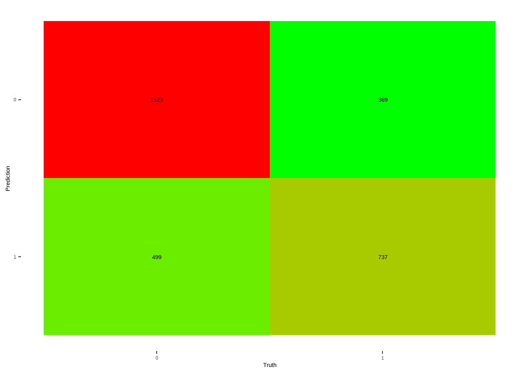

TRUE

## XGBoost

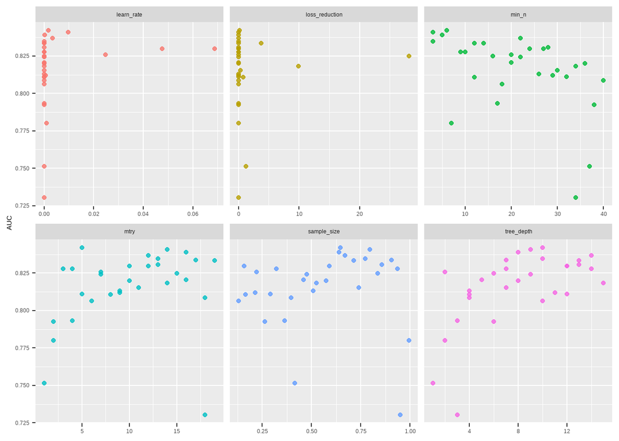

TRUE

```
## == Workflow ====================================================================
## Preprocessor: Formula
## Model: boost_tree()
##
## -- Preprocessor ----------------------------------------------------------------
## ChurnStatus ~ .
##
## -- Model -----------------------------------------------------------------------
## Boosted Tree Model Specification (classification)
##
## Main Arguments:
##   mtry = 5
##   trees = 1000
##   min_n = 6
##   tree_depth = 10
##   learn_rate = 0.00172951857619606
##   loss_reduction = 0.138611038304029
##   sample_size = 0.647125707699452
##
## Computational engine: xgboost
```

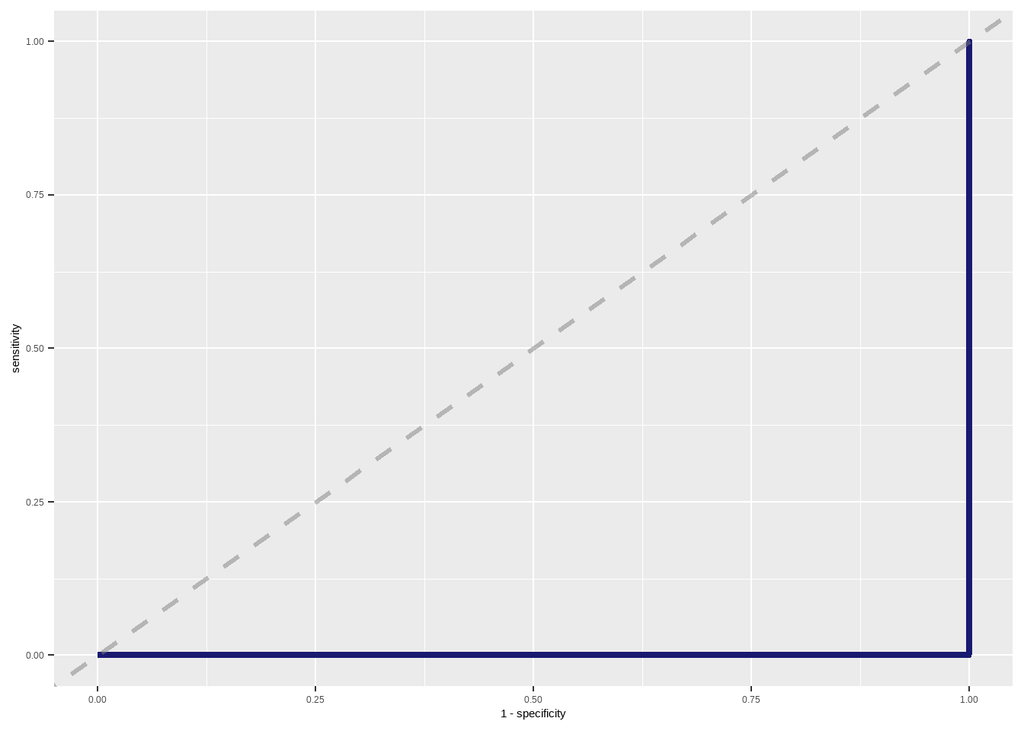

TRUE

```
## Confusion Matrix and Statistics
##
##
##        0    1
##   0 2022    0
##   1    0 1106
##
##                Accuracy : 1
##                  95% CI : (0.9988, 1)
##     No Information Rate : 0.6464
##     P-Value [Acc > NIR] : < 2.2e-16
##
##                   Kappa : 1
##
##  Mcnemar's Test P-Value : NA
##
##             Sensitivity : 1.0000
##             Specificity : 1.0000
##          Pos Pred Value : 1.0000
##          Neg Pred Value : 1.0000
##              Prevalence : 0.6464
##          Detection Rate : 0.6464
##    Detection Prevalence : 0.6464
##       Balanced Accuracy : 1.0000
##
##        'Positive' Class : 0
##
```